# Actividad - Estadística descriptiva

José Carlos Ortiz Bayliss

## Instrucciones

Realiza las operaciones que se describen a continuación. Recuerda que existen muchas formas de lograr los resultados esperados. Aunque la solución pueda no parecerte “elegante”, en este momento nos enfocaremos en que funcione correctamente. Eso es suficiente para que la solución sea aceptada.

Antes de comenzar, ejecuta el siguiente código en R. Este código generará tres vectores numéricos con valores aleatorios (el rango de valores varía para cada vector). Adicionalmente, algunas de las posiciones de el primer vector han sido modificadas para contener `NA`s.

```r
set.seed(12345)
numbersA <- runif(150, -10, 10)
ids <- sample(1:length(numbersA), sample(1:50, 1))
numbersA[ids] <- NA
numbersB <- rf(150, 5, 20)
numbersC <- numbersA + runif(150, -1, 1)
```

**No es necesario entregar algún archivo como parte de tu solución**. Sólo es necesario que selecciones la opción correcta en cada una de las preguntas de la actividad.

### Ejercicio 1

La función `is.na` permite identificar qué valores son `NA`. Ejecuta el código `which(is.na(numbersA))` para revisar qué posiciones en el vector `numbersA` son `NA`s. Partiendo del código anterior, indica que fracción de los datos en el vector `numbersA` son `NA`s.

**Hint**

-La función `length` puede ser de utilidad. Puedes solicitar más información sobre esta función ejecutando `?length` en la consola.

**Ver solución I**

```r
length(which(is.na(numbersA))) / length(numbersA)
```

```
## [1] 0.2
```

**Ver solución II**

```r
library(dplyr)
numbersA %>%
  is.na() %>%
  which() %>%
  length() %>%
  `/`(length(numbersA))
```

```
## [1] 0.2
```

### Ejercicio 2

¿Cuál es el promedio de los valores en el vector `numbersA`? No olvides que, como el vector contiene valores `NA`, es necesario usar el parámetro `na.rm = TRUE` al momento de calcular el promedio con la función `mean`. Redondea tu resultado a tres dígitos decimales.

**Ver solución**

```r
round(mean(numbersA, na.rm = TRUE), 3)
```

```
## [1] 0.644
```

### Ejercicio 3

El código `numbersA[is.na(numbersA)] <- 0` permitiría sustituir todos los valores `NA`s en el vector `numbersA` por ceros. Sin embargo, al hacer esto, la variable perdería los valores `NA` para siempre. Por esta razón, cree una nueva variable, `copied` (que tendrá todos los valores de `numbersA`; será una copia exacta). En `copied`, reemplace todos los valores `NA` por ceros. ¿Cuál es el promedio de los valores que contiene el vector `copied` después de reemplazar los valores `NA`s por ceros? Redondea tu resultado a tres dígitos decimales.

**Ver solución**

```r
copied <-numbersA
copied[is.na(copied)] <- 0
round(mean(copied, na.rm = TRUE), 3)
```

```
## [1] 0.516
```

### Ejercicio 4

Crea nuevamente la variable `copied` a partir del vector `numbersA` (`copied` será una copia exacta de `numbersA`). En `copied`, reemplace todos los valores `NA` por el promedio de los valores (no olvides usar el parámetro `na.rm = TRUE`). ¿Cuál es el promedio de los valores que contiene el vector `copied` después de reemplazar los valores `NA`s por el promedio en `copied`? Redondea tu resultado a tres dígitos decimales.

**Ver solución**

```r
copied <-numbersA
copied[is.na(copied)] <- mean(copied, na.rm = TRUE)
round(mean(copied), 3)
```

```
## [1] 0.644
```

### Ejercicio 5

Crea nuevamente la variable `copied` a partir del vector `numbersA` (`copied` será una copia exacta de `numbers`). En `copied`, reemplace todos los valores `NA` por el promedio de los valores (no olvides usar el parámetro `na.rm = TRUE`). ¿Cuál es el promedio de los valores que contiene el vector `copied` después de reemplazar los valores `NA`s por el promedio en `copied`? Redondea tu resultado a tres dígitos decimales.

**Ver solución**

```r
copied <-numbersA
copied[is.na(copied)] <- mean(copied, na.rm = TRUE)
round(mean(copied), 3)
```

```
## [1] 0.644
```

### Ejercicio 6

¿Cuál de los tres vectores tiene la mayor media? ¿Cuál tiene la mayor mediana?

**Ver solución**

```r
mean(numbersA, na.rm = TRUE)
```

```
## [1] 0.644415
```

```r
mean(numbersB, na.rm = TRUE)
```

```
## [1] 1.033051
```

```r
mean(numbersC, na.rm = TRUE)
```

```
## [1] 0.643508
```

```r
median(numbersA, na.rm= TRUE)
```

```
## [1] 1.035146
```

```r
median(numbersB, na.rm = TRUE)
```

```
## [1] 0.8279387
```

```r
median(numbersC, na.rm = TRUE)
```

```
## [1] 1.450419
```

### Ejercicio 7

Modifique el elemento más pequeño del vector `numbersB`, deforma que su valor actual se multiplique por 10. Asegúrate de sobreescribir el vector `numbersB`, ya que quedará modificado a partir de este momento. ¿Que sucede con la media del vector `numbersB`? ¿Qué sucede con la mediana?

**Ver solución**

```r
mean(numbersB, na.rm= TRUE)
```

```
## [1] 1.033051
```

```r
median(numbersB, na.rm= TRUE)
```

```
## [1] 0.8279387
```

```r
numbersB[which.min(numbersB)] <- numbersB[which.min(numbersB)] * 10
mean(numbersB, na.rm = TRUE)
```

```
## [1] 1.043104
```

```r
median(numbersB, na.rm= TRUE)
```

```
## [1] 0.8308519
```

### Ejercicio 8

¿Cuál es el rango de los datos en el vector `numbersB`?

**Ver solución**

```r
max(numbersB) - min(numbersB)
```

```
## [1] 4.409859
```

### Ejercicio 9

¿Cuál es el rango intercuartil de los datos en el vector `numbersC`?

**Ver solución**

```r
IQR(numbersC, na.rm = TRUE)
```

```
## [1] 10.43354
```

### Ejercicio 10

¿Cuál es la varianza de los datos en el vector `numbersC`?

**Ver solución**

```r
var(numbersC, na.rm = TRUE)
```

```
## [1] 35.8217
```

### Ejercicio 11

¿Cuál es el coeficiente de variación de los datos en el vector `numbersC`?

**Ver solución**

```r
sd(numbersC, na.rm = TRUE) / mean(numbersC, na.rm = TRUE)
```

```
## [1] 9.300775
```

### Ejercicio 12

Identifique si existe correlación entre los datos de los vectores `numbersA` y `numbersC`. ¿Cuál es el coeficiente de correlación entre ambas variables? Redondea tu resultado a tres dígitos decimales.

**Ver solución**

```r
cor(numbersA, numbersC, use = "pairwise.complete.obs")
```

```
## [1] 0.9952374
```

### Ejercicio 13

Utilizando el coeficiente de correlación, identifique si existe correlación entre los datos de los vectores `numbersA` y `numbersB`. ¿Cuál es el coeficiente de correlación entre ambas variables? Redondea tu resultado a tres dígitos decimales.

**Ver solución**

```r
cor(numbersA, numbersB, use = "pairwise.complete.obs")
```

```
## [1] -0.06088318
```

### Ejercicio 14

Un coeficiente de correlación cercano a uno sugiere que, cuando una de las variables se incrementa en una unidad, la otra variable se incrementa en un valor similar. En otras palabras, los incrementos de una de las variables se ven reflejados por un incremento del mismo signo y similar magnitud en la otra variable. Usando como referencia lo anterior, cuál de las siguientes gráficas describe mejor un coeficiente de correlación cercano a 0?

**Ver solución**

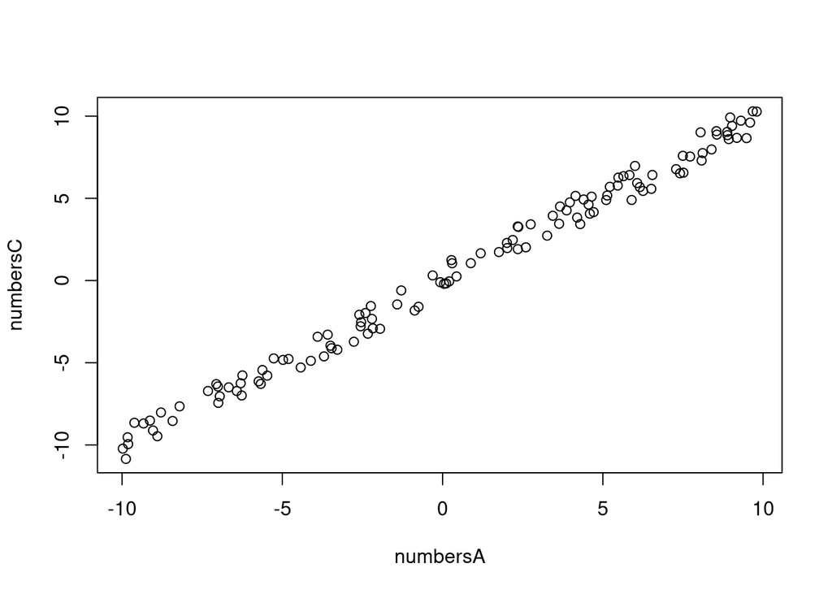

```r
plot(numbersA, numbersC)
```

```r
cor(numbersA, numbersC, use = "pairwise.complete.obs")
```

```
## [1] 0.9952374
```

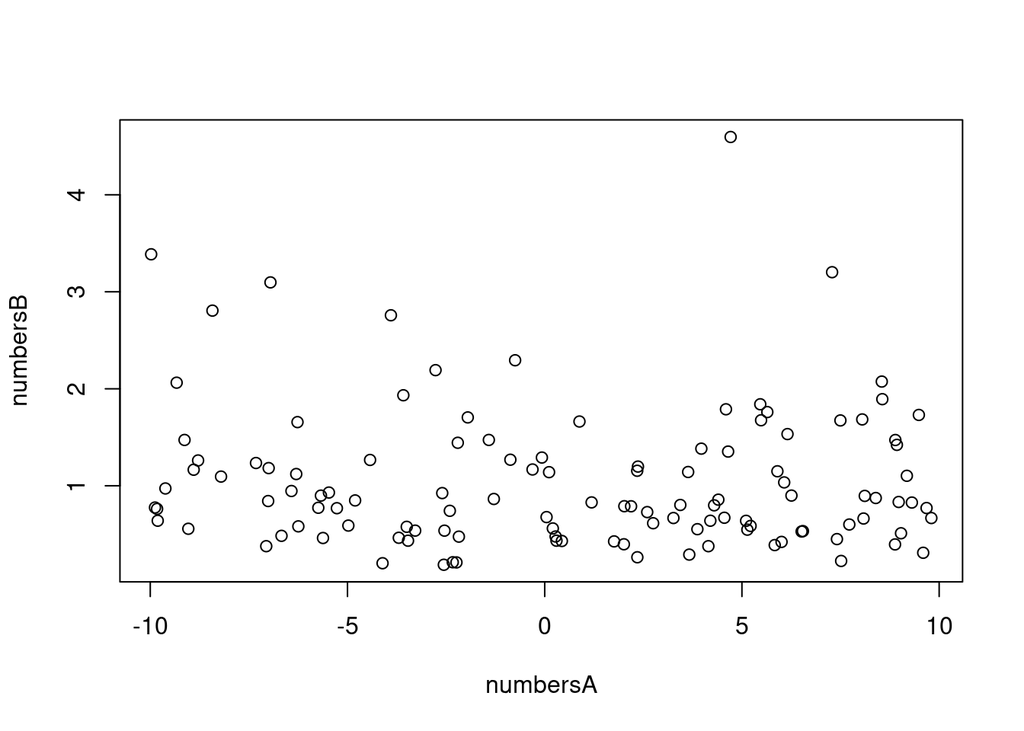

```r
plot(numbersA, numbersB)
```

```r
cor(numbersA, numbersB, use = "pairwise.complete.obs")
```

```
## [1] -0.06088318
```

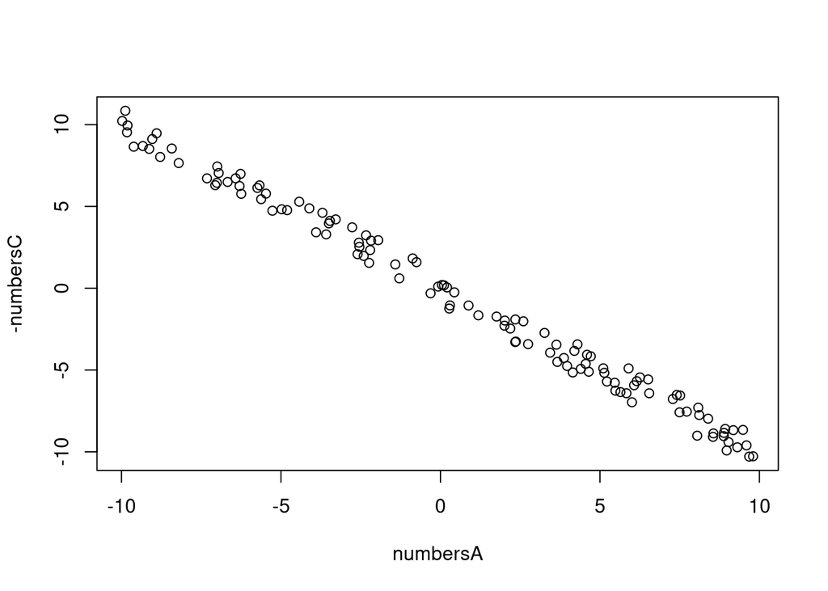

```r
plot(numbersA, -numbersC)
```

```r
cor(numbersA, -numbersC, use = "pairwise.complete.obs")
```

```
## [1] -0.9952374
```

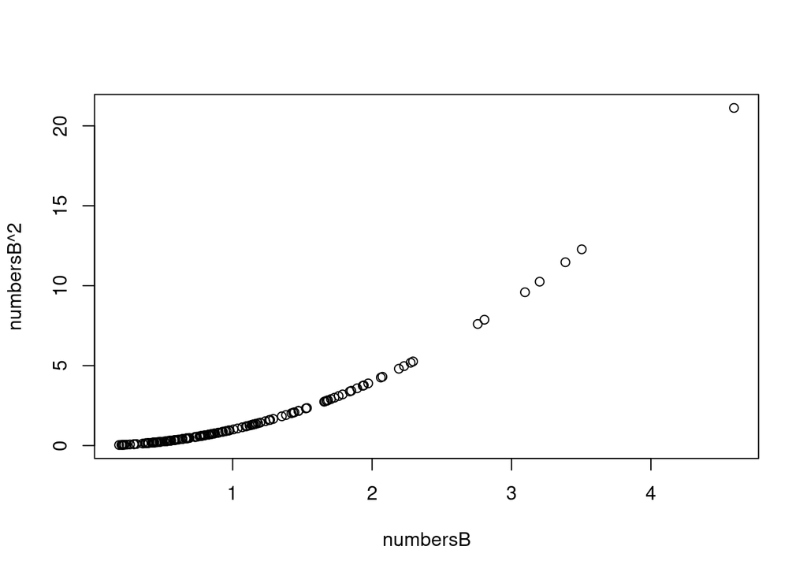

```r
plot(numbersB, numbersB**2)
```

```r
cor(numbersB, numbersB**2, use = "pairwise.complete.obs")
```

```
## [1] 0.9363426
```